# Project: No-Show Appointments in Brazil

- Introduction
- Data Wrangling & Cleaning
- Exploratory Data Analysis
- Conclusions

## Introduction

> The No-show appointment dataset has various characteristics of patients and their medical appointments in Brazil. This dataset includes information about a patient's conditions, including diabetes, hipertension, alcoholism, etc. Also, there is information regarding the appointment day,and other factors regarding the appointment, such as whether or not the patient received a sms and whether or not the patient actually showed up on the scheduled appointment day.

> In this report, I will use the age, hipertension and sms received variables (independent) to explore the no-show variable (dependent). I would like to find what a no-show patient looks like in comparison to a patient that did show up.

### Research Questions

> What is the age distribution of a no-show patient vs a show patient? Were those that received a sms likely to show up for their appointment? Did patients with a hipertension condition show up to appointments more than those without the condition?

## Data Wrangling & Cleaning

### Getting to Know the Dataset

> The first step is to import all necessary packages to analyze the dataset. Then, I will load the no-show appointment csv file and get an idea of what type of data/variables are within the dataset.

```python
import pandas as pd
import numpy as np
import matplotlib.pyplot as plt
%matplotlib inline
```

```python
df = pd.read_csv('noshowappointments-kagglev2-may-2016.csv')
df.head()
```

|  | PatientId | AppointmentID | Gender | ScheduledDay | AppointmentDay | Age | Neighbourhood | Scholarship | Hipertension | Diabetes | Alcoholism | Handcap | SMS_received | No-show |
| --- | --- | --- | --- | --- | --- | --- | --- | --- | --- | --- | --- | --- | --- | --- |
| 0 | 2.987250e+13 | 5642903 | F | 2016-04-29T18:38:08Z | 2016-04-29T00:00:00Z | 62 | JARDIM DA PENHA | 0 | 1 | 0 | 0 | 0 | 0 | No |
| 1 | 5.589978e+14 | 5642503 | M | 2016-04-29T16:08:27Z | 2016-04-29T00:00:00Z | 56 | JARDIM DA PENHA | 0 | 0 | 0 | 0 | 0 | 0 | No |
| 2 | 4.262962e+12 | 5642549 | F | 2016-04-29T16:19:04Z | 2016-04-29T00:00:00Z | 62 | MATA DA PRAIA | 0 | 0 | 0 | 0 | 0 | 0 | No |
| 3 | 8.679512e+11 | 5642828 | F | 2016-04-29T17:29:31Z | 2016-04-29T00:00:00Z | 8 | PONTAL DE CAMBURI | 0 | 0 | 0 | 0 | 0 | 0 | No |
| 4 | 8.841186e+12 | 5642494 | F | 2016-04-29T16:07:23Z | 2016-04-29T00:00:00Z | 56 | JARDIM DA PENHA | 0 | 1 | 1 | 0 | 0 | 0 | No |

### Part 1. Making the Dataset More Readable

> In this step, I decided that it would be easier to work with columns that were all lowercase. This was necessary because when I am using the column names in my analysis, I can easily recall the format of the columns.

> Next, I renamed three different columns to make them easier to read and use while working with the data. More specifically, I wanted to change the 'no-show' column to 'no_show', as it is a standard way to include spaces or hyphens for column names in python.

> Lastly, I wanted to look at how many columns and entries were in the dataset and to check for null values.

```python
df.columns = df.columns.str.lower()

df = df.rename(columns = {"no-show": "no_show", "scheduledday": "scheduled_day", "neighbourhood":"neighborhood"})
df.info()
```

```
<class 'pandas.core.frame.DataFrame'>
RangeIndex: 110527 entries, 0 to 110526
Data columns (total 14 columns):
 #   Column          Non-Null Count   Dtype
---  ------          --------------   -----
 0   patientid       110527 non-null  float64
 1   appointmentid   110527 non-null  int64
 2   gender          110527 non-null  object
 3   scheduled_day   110527 non-null  object
 4   appointmentday  110527 non-null  object
 5   age             110527 non-null  int64
 6   neighborhood    110527 non-null  object
 7   scholarship     110527 non-null  int64
 8   hipertension    110527 non-null  int64
 9   diabetes        110527 non-null  int64
 10  alcoholism      110527 non-null  int64
 11  handcap         110527 non-null  int64
 12  sms_received    110527 non-null  int64
 13  no_show         110527 non-null  object
dtypes: float64(1), int64(8), object(5)
memory usage: 11.8+ MB
```

### Part 1. Making the Dataset More Readable (cont'd.)

> Here, I wanted a clean visual of the data in its columns, thus I wanted to change the format of the date and time for the scheduled_day and appointmentday columns. Also, it was not necessary to have the timestamp, as I wouldn't be using it for my analysis.

> In addition, I chose to drop the patientid and appointmentid columns because they seemed like extras that weren't nexessary to have in my analysis. I wouldn't be using the particular patient's id or appointment id to do any analyzing or exploring of the data.

```python
df['scheduled_day'] = pd.to_datetime(df['scheduled_day']).dt.date

df['appointmentday'] = pd.to_datetime(df['appointmentday']).dt.date

df.drop(['patientid', 'appointmentid'], axis = 1, inplace=True)

df.head()
```

|  | gender | scheduled_day | appointmentday | age | neighborhood | scholarship | hipertension | diabetes | alcoholism | handcap | sms_received | no_show |
| --- | --- | --- | --- | --- | --- | --- | --- | --- | --- | --- | --- | --- |
| 0 | F | 2016-04-29 | 2016-04-29 | 62 | JARDIM DA PENHA | 0 | 1 | 0 | 0 | 0 | 0 | No |
| 1 | M | 2016-04-29 | 2016-04-29 | 56 | JARDIM DA PENHA | 0 | 0 | 0 | 0 | 0 | 0 | No |
| 2 | F | 2016-04-29 | 2016-04-29 | 62 | MATA DA PRAIA | 0 | 0 | 0 | 0 | 0 | 0 | No |
| 3 | F | 2016-04-29 | 2016-04-29 | 8 | PONTAL DE CAMBURI | 0 | 0 | 0 | 0 | 0 | 0 | No |
| 4 | F | 2016-04-29 | 2016-04-29 | 56 | JARDIM DA PENHA | 0 | 1 | 1 | 0 | 0 | 0 | No |

### Part 2. Making the Dataset More Readable ~ Unrealistic Values in the Dataset

> Now that my data looked more digestible, I needed to look at the descriptive statistics of the dataset to see if there were any values in the rows that didn't seem correct.

> I found that the minimum age was -1, which is quite unrealistic, and therefore, I deleted this entry.

```python
df.describe()
```

|  | age | scholarship | hipertension | diabetes | alcoholism | handcap | sms_received |
| --- | --- | --- | --- | --- | --- | --- | --- |
| count | 110527.000000 | 110527.000000 | 110527.000000 | 110527.000000 | 110527.000000 | 110527.000000 | 110527.000000 |
| mean | 37.088874 | 0.098266 | 0.197246 | 0.071865 | 0.030400 | 0.022248 | 0.321026 |
| std | 23.110205 | 0.297675 | 0.397921 | 0.258265 | 0.171686 | 0.161543 | 0.466873 |
| min | -1.000000 | 0.000000 | 0.000000 | 0.000000 | 0.000000 | 0.000000 | 0.000000 |
| 25% | 18.000000 | 0.000000 | 0.000000 | 0.000000 | 0.000000 | 0.000000 | 0.000000 |
| 50% | 37.000000 | 0.000000 | 0.000000 | 0.000000 | 0.000000 | 0.000000 | 0.000000 |
| 75% | 55.000000 | 0.000000 | 0.000000 | 0.000000 | 0.000000 | 0.000000 | 1.000000 |
| max | 115.000000 | 1.000000 | 1.000000 | 1.000000 | 1.000000 | 4.000000 | 1.000000 |

```python
df.query('age < 0')

df.drop([99832], inplace=True)
```

[output not shown]

## Exploratory Data Analysis

### Finalized Data - Single Variable Investigations

> I also wanted to take a look at the gender and scholarship breakdown of the dataset, as quantitative values. This provides another angle to visualize the dataset.

```python
df.describe()
```

|  | age | scholarship | hipertension | diabetes | alcoholism | handcap | sms_received |
| --- | --- | --- | --- | --- | --- | --- | --- |
| count | 110526.000000 | 110526.000000 | 110526.000000 | 110526.000000 | 110526.000000 | 110526.000000 | 110526.000000 |
| mean | 37.089219 | 0.098266 | 0.197248 | 0.071865 | 0.030400 | 0.022248 | 0.321029 |
| std | 23.110026 | 0.297676 | 0.397923 | 0.258266 | 0.171686 | 0.161543 | 0.466874 |
| min | 0.000000 | 0.000000 | 0.000000 | 0.000000 | 0.000000 | 0.000000 | 0.000000 |
| 25% | 18.000000 | 0.000000 | 0.000000 | 0.000000 | 0.000000 | 0.000000 | 0.000000 |
| 50% | 37.000000 | 0.000000 | 0.000000 | 0.000000 | 0.000000 | 0.000000 | 0.000000 |
| 75% | 55.000000 | 0.000000 | 0.000000 | 0.000000 | 0.000000 | 0.000000 | 1.000000 |
| max | 115.000000 | 1.000000 | 1.000000 | 1.000000 | 1.000000 | 4.000000 | 1.000000 |

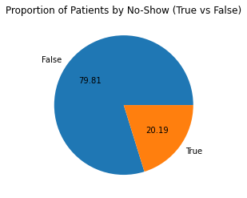

```python
noshow_counts = df['no_show'].value_counts()
noshow_total = df['no_show'].count()

noshow_proportion = noshow_counts / noshow_total
labels = ['False', 'True']
plt.pie(noshow_proportion, labels=labels, autopct='%.2f')

plt.title('Proportion of Patients by No-Show (True vs False)')
```

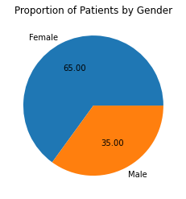

```python
gender_counts = df['gender'].value_counts()
gender_total = df['gender'].count()

gender_proportion = gender_counts / gender_total
labels = ['Female', 'Male']

plt.pie(gender_proportion, labels=labels, autopct='%.2f')

plt.title('Proportion of Patients by Gender')
```

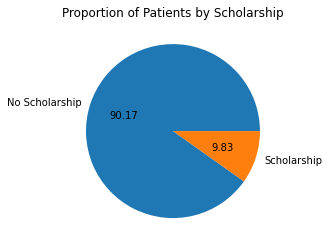

```python
scholar_counts = df['scholarship'].value_counts()
scholar_total = df['scholarship'].count()

scholar_proportion = scholar_counts / scholar_total
labels = ['No Scholarship', 'Scholarship']

plt.pie(scholar_proportion, labels=labels, autopct='%.2f')
plt.title('Proportion of Patients by Scholarship')
```

### Distribution of No-Show and Show by Age - Multiple Variable Investigation

> To further explore this dataset, I used the no-show variable as a mask to determine the average age of this particular variable. I also created the mask to make the no_show variable more readable, meaning that if there was a no_show then the return would be True. Then, I went on to visualize the distribution of ages for both those who showed up to the appointment and those that did not.

> On the graph, I overlayed both those who did show and did not show. Of those that did not show for their appointment, the ages skewed more right than those that did not show. It is important to note that there were significantly more people who showed than did not show.

```python
noshows = df['no_show'] == 'Yes'
show = df['no_show'] == 'No'
```

```python
df.age[noshows].mean()
```

```
34.31766656212196
```

```python
df.age[show].mean()
```

```
37.790504154999034
```

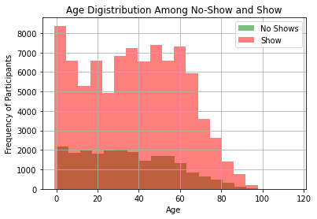

```python
df.age[noshows].hist(alpha = 0.5, bins = 20, label = 'No Shows', color = 'g')
df.age[show].hist(alpha = 0.5, bins = 20, label = 'Show', color = 'r');
plt.legend()
plt.title('Age Digistribution Among No-Show and Show')
plt.ylabel('Frequency of Participants')
plt.xlabel('Age')
```

### Bar Graph of No-Show and Show by SMS Received - Multiple Variable Investigation

> Here, I am looking at the average number of no-shows and shows among those who did and did not receive a sms.

> Before I could move forth, I had to use proportions for the binary values in the sms_received variable.

> I first grouped the sms_received variable and the no_show variable and counted how many patients were in each grouping. Then, I grouped the total of each value in the sms_received variable. These were then used to create the proportions that I graphed in a bar chart.

> It seems to be that the a higher proportion of those who did show up for their appointments, did not receive a sms. Furthermore, there was a higher proportion of those that did not show up for their appointment, that actually did end up receiving a sms.

```python
df['sms_received'][noshows].mean()
```

```
0.43837089475334917
```

```python
df['sms_received'][show].mean()
```

```
0.29133742220005215
```

```python
def col_count(col):
    col = df.groupby([col, noshows]).count()['handcap']

    return col
```

```python
sms_count = col_count('sms_received')
```

```python
sms_totals = df.groupby('sms_received').count()['handcap']
sms_totals
```

```
sms_received
0    75044
1    35482
Name: handcap, dtype: int64
```

```python
sms_yes_proportion = sms_count[1]/sms_totals[1]
sms_yes_proportion
```

```
no_show
False    0.724255
True     0.275745
Name: handcap, dtype: float64
```

```python
sms_no_proportion = sms_count[0]/sms_totals[0]
sms_no_proportion
```

```
no_show
False    0.832965
True     0.167035
Name: handcap, dtype: float64
```

```python
ind = np.arange(len(sms_yes_proportion))
width = 0.35
```

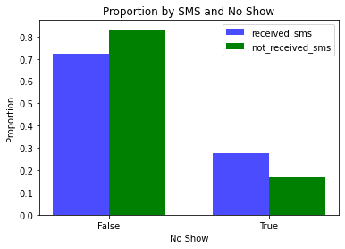

```python
sms_yes_bar = plt.bar(ind, sms_yes_proportion, width, color = 'b', alpha = 0.7, label= 'received_sms')
sms_no_bar = plt.bar(ind + width, sms_no_proportion, width, color = 'g', label = 'not_received_sms')

plt.ylabel('Proportion')
plt.xlabel('No Show')
plt.title('Proportion by SMS and No Show')
locations = ind + width / 2
labels = ['False', 'True']
plt.xticks(locations, labels)

plt.legend()
```

### Bar Graph of No-Show and Show by Hipertension - Multiple Variable Investigation

> I adopted the same methodologies for the hipertension variable. First, I used the col_count function I previously defined to then calculate the proportions for the 'Hipertension' column, which I later graphed.

> I calculated the proportions of those with and without hipertension among the no-show and show appointments. This was followed by a bar chart with each proportion of hipertension vs no hipertension.

> Interestingly, I found that there was a higher proportion of people without hipertension that did not show up for their appointment. Also, there was a higher proportion of those with hipertension that did show up to their appointment.

```python
df.hipertension[noshows].mean()
```

```
0.16900398763385457
```

```python
df.hipertension[show].mean()
```

```
0.20439420907637715
```

```python
hiper_count = col_count('hipertension')
hiper_count
```

[output not shown]

```python
hiper_totals = df.groupby('hipertension').count()['handcap']
hiper_totals
```

[output not shown]

```python
not_hiper_proportion = hiper_count[0]/hiper_totals[0]
not_hiper_proportion
```

```
no_show
False    0.790963
True     0.209037
Name: handcap, dtype: float64
```

```python
hiper_proportion = hiper_count[1]/hiper_totals[1]
hiper_proportion
```

```
no_show
False    0.82698
True     0.17302
Name: handcap, dtype: float64
```

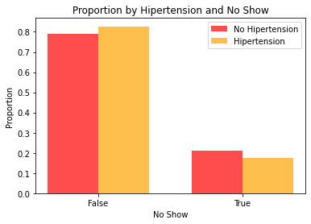

```python
ind = np.arange(len(hiper_proportion))
width = 0.35

not_hiper_bar = plt.bar(ind, not_hiper_proportion, width, color = 'r', alpha = 0.7, label = 'No Hipertension')
hiper_bar = plt.bar(ind + width, hiper_proportion, width, color = 'orange', alpha = 0.7, label = 'Hipertension')

plt.title('Proportion by Hipertension and No Show')
plt.xlabel('No Show')
plt.ylabel('Proportion')
location = ind + width / 2
label = ['False', 'True']
plt.xticks(location, label)
plt.legend()
```

## Conclusions

> Overall, there were more patients that showed up for their appointments than those that did not. The average age of those that did show up for their appointments was about 38, which is roughly four years older than (34) those that did not show up. Hence, it seems that younger patients are more likely to not show up for their appointment.

> Next, I analyzed the sms_received variable among no-show and show. I found that those that did not show up for their appointments were more likely to have received a sms, on average (.43 no_show vs .29 show). Moreover, among those that did not show up for their appointments were actually the patients that had a higher porportion of sms received.

### Limitations

> In the dataset, the neighborhood column is interesting and could have been helpful in this analysis. Instead of including only the neighborhood name, I could have used a column for 'distance traveled in miles'. This would have given numerical data that could have been used to test relationships between distance and no-show appointments.

> Lastly, this dataset was made up of many coulmns that were binary values, making it challenging to dive deep into the analysis and create particular graphs.